# Evolution of Peace in Experimental Social Networks

## Analysis

### 1. What are the characteristics of people who chose to attack (=performing costly sanction)? (social demographic emotional) (who include attack in their behavior strategy?) We can evaluate this question using two approaches:

#### a) Using the binary attack indicator (so factors influencing specific individual choices)

```r
names(data1)
```

```
 [1] "superid"               "round"                 "game"                  "age"                   "gender"                "country_3cat"
 [7] "showScore"             "initial_score"         "payoff"                "cumulativePayoff"      "cPayoffS"              "WealthLevel"
[13] "behavior_coop"         "behavior_defect"       "behavior_punish"       "local_rate_coop"       "local_rate_defect"     "local_rate_punish"
[19] "happ"                  "behaviorTime"          "degree"                "e_degree"              "initial_coop"          "initial_defect"
[25] "initial_punish"        "initial_score_lag"     "payoff_lag"            "cumulativePayoff_lag"  "cPayoffS_lag"          "WealthLevel_lag"
[31] "behavior_coop_lag"     "local_rate_coop_lag"   "behavior_defect_lag"   "local_rate_defect_lag" "behavior_punish_lag"   "local_rate_punish_lag"
[37] "degree_lag"            "happ_lag"              "behaviorTime_lag"      "log_behaviorTime"      "log_behaviorTime_lag"
```

```r
# Make the categorical behavior variable
data1b = data1 %>% mutate(behavior = case_when(behavior_coop == 1 ~ "C",
                                      behavior_defect == 1 ~ "D",
                                      behavior_punish == 1 ~ "P"),
                 behavior_lag = case_when(behavior_coop_lag == 1 ~ "C",
                                          behavior_defect_lag ==1 ~ "D",
                                          behavior_punish_lag == 1 ~ "P"))
data1_cc = na.omit(data1b)
dim(data1_cc)
```

```
[1] 8089   43
```

## Binary outcomes

```r
m1 = glmer(behavior_punish ~ showScore + age + gender + behavior_coop_lag + local_rate_coop_lag + behavior_punish_lag + local_rate_punish_lag + cPayoffS_lag + degree_lag + happ_lag + log_behaviorTime + log_behaviorTime_lag + factor(round) + (1|game) + (1|superid), data = data1_cc, family = binomial, nAGQ=0, control = glmerControl(optimizer = c("bobyqa"), optCtrl=list(maxfun=2e5), calc.derivs=FALSE))

se = sqrt(diag(vcov(m1)))
# table of estimates with 95% CI
tab_m1 = cbind(Est = fixef(m1), LL = fixef(m1) - 1.96 * se, UL = fixef(m1) + 1.96 * se)
round(exp(tab_m1), digits = 3)[1:13,]
```

```
                        Est    LL    UL
(Intercept)           0.002 0.000 0.016
showScore             1.252 0.708 2.214
age                   0.996 0.979 1.014
gendermale            1.502 0.853 2.644
behavior_coop_lag     1.375 0.976 1.936
local_rate_coop_lag   0.349 0.200 0.609
behavior_punish_lag   2.049 1.443 2.910
local_rate_punish_lag 3.566 1.421 8.951
cPayoffS_lag          0.697 0.547 0.887
degree_lag            0.988 0.929 1.051
happ_lag              0.952 0.825 1.099
log_behaviorTime      2.109 1.447 3.074
log_behaviorTime_lag  0.937 0.636 1.379
```

```r
m2 = glmer(behavior_punish ~ showScore + age + gender + behavior_coop_lag + local_rate_coop_lag + behavior_punish_lag + local_rate_punish_lag + cPayoffS_lag + degree_lag + happ_lag + log_behaviorTime  + factor(round) + (1|game) + (1|superid), data = data1_cc, family = binomial, nAGQ=0, control = glmerControl(optimizer = c("bobyqa"), optCtrl=list(maxfun=2e5), calc.derivs=FALSE))
se = sqrt(diag(vcov(m2)))
# table of estimates with 95% CI
tab_m2 = cbind(Est = fixef(m2), LL = fixef(m2) - 1.96 * se, UL = fixef(m2) + 1.96 * se)
round(exp(tab_m2), digits = 3)[1:12,]
```

```
                        Est    LL    UL
(Intercept)           0.001 0.000 0.008
showScore             1.249 0.706 2.208
age                   0.996 0.979 1.014
gendermale            1.502 0.853 2.645
behavior_coop_lag     1.375 0.976 1.936
local_rate_coop_lag   0.349 0.200 0.609
behavior_punish_lag   2.042 1.439 2.897
local_rate_punish_lag 3.545 1.414 8.891
cPayoffS_lag          0.698 0.548 0.888
degree_lag            0.988 0.929 1.051
happ_lag              0.952 0.825 1.099
log_behaviorTime      2.095 1.440 3.047
```

```r
m3 = glmer(behavior_punish ~ showScore + age + gender + behavior_coop_lag + local_rate_coop_lag + behavior_punish_lag + local_rate_punish_lag + cPayoffS_lag + degree_lag + happ_lag+ factor(round) + (1|game) + (1|superid), data = data1_cc, family = binomial, nAGQ=0, control = glmerControl(optimizer = c("bobyqa"), optCtrl=list(maxfun=2e5), calc.derivs=FALSE))
se = sqrt(diag(vcov(m3)))
# table of estimates with 95% CI
tab_m3 = cbind(Est = fixef(m3), LL = fixef(m3) - 1.96 * se, UL = fixef(m3) + 1.96 * se)
round(exp(tab_m3), digits = 3)[1:11,]
```

```
                        Est    LL    UL
(Intercept)           0.022 0.008 0.065
showScore             1.295 0.720 2.330
age                   0.996 0.979 1.014
gendermale            1.483 0.835 2.632
behavior_coop_lag     1.380 0.979 1.943
local_rate_coop_lag   0.344 0.197 0.599
behavior_punish_lag   2.012 1.420 2.852
local_rate_punish_lag 3.418 1.364 8.564
cPayoffS_lag          0.684 0.537 0.871
degree_lag            0.990 0.930 1.053
happ_lag              0.954 0.827 1.101
```

#### Trying model 3 with categorical rate

```r
data1_cc$local_rate_punish_cat = case_when(data1_cc$local_rate_punish_lag == 0 ~ 0,
                                          data1_cc$local_rate_punish_lag > 0 & data1_cc$local_rate_punish_lag <= 0.15 ~ 1,
                                          data1_cc$local_rate_punish_lag > 0.15 ~ 2)
xtabs(~behavior_punish + local_rate_punish_cat, data1_cc)
```

```
               local_rate_punish_cat
behavior_punish    0    1    2
              0 5847  756 1044
              1  305   40   97
```

```r
m3_cat = glmer(behavior_punish ~ showScore + age + gender + behavior_coop_lag + local_rate_coop_lag + behavior_punish_lag + factor(local_rate_punish_cat) +  cPayoffS_lag + degree_lag + happ_lag + factor(round) + (1|game) + (1|superid), data = data1_cc, family = binomial, nAGQ=0, control = glmerControl(optimizer = c("bobyqa"), optCtrl=list(maxfun=2e5), calc.derivs=FALSE))
se = sqrt(diag(vcov(m3_cat)))
# table of estimates with 95% CI
tab_m3cat = cbind(Est = fixef(m3_cat), LL = fixef(m3_cat) - 1.96 * se, UL = fixef(m3_cat) + 1.96 * se)
round(exp(tab_m3cat), digits = 3)[1:12,]
```

```
                                 Est    LL    UL
(Intercept)                    0.023 0.008 0.065
showScore                      1.294 0.723 2.318
age                            0.996 0.979 1.014
gendermale                     1.475 0.831 2.618
behavior_coop_lag              1.389 0.986 1.958
local_rate_coop_lag            0.337 0.194 0.585
behavior_punish_lag            2.030 1.431 2.880
factor(local_rate_punish_cat)1 1.089 0.682 1.740
factor(local_rate_punish_cat)2 1.630 1.162 2.286
cPayoffS_lag                   0.687 0.540 0.876
degree_lag                     0.987 0.925 1.052
happ_lag                       0.959 0.831 1.106
```

#### 1b) Add more categories to category 2?

Try 4 categories (0-24%, 25-49%, 50-74%, 75-100%) for cooperation to test for dose response.

```r
data1_cc$local_rate_punish_cat4 = case_when(data1_cc$local_rate_punish_lag >=0 & data1_cc$local_rate_punish_lag < 0.24 ~ 0,
                                            data1_cc$local_rate_punish_lag >=0.25 & data1_cc$local_rate_punish_lag < 0.49 ~ 1,
                                            data1_cc$local_rate_punish_lag >=0.5 & data1_cc$local_rate_punish_lag < 0.74 ~ 2,
                                            data1_cc$local_rate_punish_lag >=0.75 & data1_cc$local_rate_punish_lag ~ 3)

data1_cc$local_rate_coop_cat4 = case_when(data1_cc$local_rate_coop_lag >=0 & data1_cc$local_rate_coop_lag < 0.24 ~ 0,
                                            data1_cc$local_rate_coop_lag >=0.25 & data1_cc$local_rate_coop_lag < 0.49 ~ 1,
                                            data1_cc$local_rate_coop_lag >=0.5 & data1_cc$local_rate_coop_lag < 0.74 ~ 2,
                                            data1_cc$local_rate_coop_lag >=0.75 & data1_cc$local_rate_coop_lag ~ 3)

round(addmargins(prop.table(xtabs(~local_rate_coop_cat4 + behavior_punish, data1_cc))), digits = 3)

round(addmargins(prop.table(xtabs(~local_rate_coop_cat4 + behavior_punish, data1_cc), margin = 1), margin = 2), digits = 3)

m3_coop_cat4 = glmer(behavior_punish ~ showScore + age + gender + behavior_coop_lag + factor(local_rate_coop_cat4) + behavior_punish_lag + local_rate_punish_lag  + cPayoffS_lag + degree_lag + happ_lag + factor(round) + (1|game) + (1|superid), data = data1_cc, family = binomial, nAGQ=0, control = glmerControl(optimizer = c("bobyqa"), optCtrl=list(maxfun=2e5), calc.derivs=FALSE))

se = sqrt(diag(vcov(m3_coop_cat4)))
# table of estimates with 95% CI
tab_m3_coop_cat4 = cbind(Est = fixef(m3_coop_cat4), LL = fixef(m3_coop_cat4) - 1.96 * se, UL = fixef(m3_coop_cat4) + 1.96 * se)
round(exp(tab_m3_coop_cat4), digits = 3)[1:12,]
```

```r
m3.1_cat = glmer(behavior_punish ~ showScore + age + gender + behavior_coop_lag + local_rate_coop_lag + behavior_punish_lag + factor(local_rate_punish_cat) + cPayoffS_lag + degree_lag + happ_lag + log_behaviorTime + factor(round) + (1|game) + (1|superid), data = data1_cc, family = binomial, nAGQ=0, control = glmerControl(optimizer = c("bobyqa"), optCtrl=list(maxfun=2e5), calc.derivs=FALSE))
se = sqrt(diag(vcov(m3_cat)))
# table of estimates with 95% CI
tab_m3.1cat = cbind(Est = fixef(m3.1_cat), LL = fixef(m3.1_cat) - 1.96 * se, UL = fixef(m3.1_cat) + 1.96 * se)
round(exp(tab_m3.1cat), digits = 3)[1:13,]
```

#### 1c) Evaluating characteristics of ever attackers

```r
ever_attackers = unique(harmdata %>% group_by(superid) %>% filter(behavior_punish == 1) %>% pull(superid))
ever_cooperator = unique(harmdata %>% group_by(superid) %>% filter(behavior_coop == 1) %>% pull(superid))

harmdata$ever_attacker = ifelse(harmdata$superid %in% ever_attackers, 1, 0)
harmdata$ever_cooperator = ifelse(harmdata$superid %in% ever_cooperator, 1, 0)

# Convert IPaddress to country
library(rgeolocate)
file = system.file("extdata","GeoLite2-Country.mmdb", package = "rgeolocate")
ipCountries = maxmind(harmdata$ipAddress, file, "country_name")
harmdata$country = ipCountries$country_name
table(harmdata$country) #messy

`%notin%` <- Negate(`%in%`)

harmdata = harmdata %>% mutate(country_3cat = case_when(country == "United States" ~ "US",
                                                        country == "India" ~ "India",
                                                        country %notin% c("United States", "India") ~ "Other"))

harmdata = harmdata %>% mutate(country_3cat = factor(country_3cat, levels = c("US", "India", "Other")))

harmdata_clean = na.omit(harmdata)

# use round 2 + take non-varying variables
# check non-varying if usable - show other sociodemographic variables
# IP address - country of origin?

harmdata_no_rep = harmdata %>% filter(round == 2)

# add PANAS variables
m4 = glmer(ever_attacker ~ showScore + age + gender + country_3cat + (1|game), data = harmdata_no_rep, family = binomial, nAGQ=0, control = glmerControl(optimizer = c("bobyqa"), optCtrl=list(maxfun=2e5), calc.derivs=FALSE))

se = sqrt(diag(vcov(m4)))
# table of estimates with 95% CI
tab_m4 = cbind(Est = fixef(m4), LL = fixef(m4) - 1.96 * se, UL = fixef(m4) + 1.96 * se)
round(exp(tab_m4), digits = 3) #Indian users more likely to choose punish?

xtabs(~country_3cat + ever_attacker, harmdata_no_rep) # maybe - have less Indian users + more punishers overall
```

**note**: Do naturally aggressive people learn to be less aggressive over games played with less aggressive players?

1c) Looking at trends of harming over every round

To see a global trend of the rate of harming over 15 rounds per each session, could you make a figure in which x axis is round, y axis is the rate of harming, and 50 linegraphs representing 50 sessions?

```r
data0_cc = na.omit(data0)

data0_sum = data0_cc %>% group_by(game, round) %>% summarize(mean_punish_rate = mean(local_rate_punish))

library(viridis)

# Messy with all 50
data0_sum %>% ggplot() +
  geom_line(aes(x= round, y = mean_punish_rate, group = factor(game), color = factor(game))) +
  scale_x_continuous(breaks = c(1, 5, 10, 15),
                   labels = c(1, 5, 10, 15)) +
  scale_color_viridis(discrete = T) +
  xlab("Round")+
  ylab("Mean Local Punish Rate") +
  theme(legend.position = c("none"))
```

```r
# Try using smooth curve
data0_sum %>% ggplot() +
  geom_smooth(aes(x= round, y = mean_punish_rate, group = factor(game), color = factor(game)),
              method = "loess", se = FALSE) +
  scale_x_continuous(breaks = c(1, 5, 10, 15),
                   labels = c(1, 5, 10, 15)) +
  scale_color_viridis(discrete = T) +
  xlab("Round")+
  ylab("Mean Local Punish Rate") +
  theme(legend.position = c("none"))
```

```r
#Clearer with groups of 25
# Games 1-25
data0_sum %>% filter(game %in% 1:25) %>% ggplot() +
  geom_smooth(aes(x= round, y = mean_punish_rate, group = factor(game), color = factor(game)),
              method = "loess", formula = y ~ x, se = FALSE) +
  scale_x_continuous(breaks = c(1, 5, 10, 15),
                   labels = c(1, 5, 10, 15)) +
  scale_color_viridis(discrete = TRUE) +
  xlab("Round")+
  ylab("Mean Local Punish Rate")+
  theme(legend.position = c("none"))
```

```r
# Games 26-50
data0_sum %>% filter(game %in% 26:50) %>% ggplot() +
  geom_smooth(aes(x= round, y = mean_punish_rate, group = factor(game), color = factor(game)),
              method = "loess", formula = y ~ x, se = FALSE) +
  scale_x_continuous(breaks = c(1, 5, 10, 15),
                   labels = c(1, 5, 10, 15)) +
  scale_color_viridis(discrete = T) +
  xlab("Round")+
  ylab("Mean Local Punish Rate") +
  theme(legend.position = c("none"))
```

#### 1d) Multinomial outcomes

First, compare P vs. C+D (should be the same as the binary ones)

```r
data1_cc_1d = data1_cc %>% mutate(behavior_punish_binary = ifelse(behavior == "P", 1, 0))

m1_1d = glmer(behavior_punish ~ showScore + age + gender + behavior_coop_lag + local_rate_coop_lag + behavior_punish_lag + local_rate_punish_lag + cPayoffS_lag + degree_lag + happ_lag + log_behaviorTime + log_behaviorTime_lag + factor(round) + (1|game) + (1|superid), data = data1_cc_1d, family = binomial, nAGQ=0, control = glmerControl(optimizer = c("bobyqa"), optCtrl=list(maxfun=2e5), calc.derivs=FALSE))

se = sqrt(diag(vcov(m1_1d)))
# table of estimates with 95% CI
tab_m1_1d = cbind(Est = fixef(m1_1d), LL = fixef(m1_1d) - 1.96 * se, UL = fixef(m1_1d) + 1.96 * se)
round(exp(tab_m1_1d), digits = 3)[1:13,] # confirmed to be same
```

Now use multinomial behavior as the outcome (without and with time)

```r
library(mclogit)
m2_1d = mblogit(behavior ~ showScore + age + gender + factor(behavior_lag) + local_rate_coop_lag + local_rate_punish_lag + cPayoffS_lag + degree_lag + happ_lag + factor(round), random = ~ 1|superid/game, data = data1_cc_1d)
```

```r
library(mgcv)

data1_cc_1d = data1_cc_1d %>% mutate(behavior = factor(behavior, levels = c("C", "D", "P")),
                                     behavior_numeric = case_when(behavior == "C" ~ 0,
                                                                  behavior == "D" ~ 1,
                                                                  behavior == "P" ~ 2))

# Multinomial with random effects
terms_list = list(behavior_numeric ~ showScore + age + gender + factor(behavior_lag) + local_rate_coop_lag + local_rate_punish_lag + cPayoffS_lag + degree_lag + happ_lag + factor(round) + s(game, bs = "re") + s(superid, bs = "re"), ~ showScore + age + gender + factor(behavior_lag) + local_rate_coop_lag + local_rate_punish_lag + cPayoffS_lag + degree_lag + happ_lag + factor(round) + s(game, bs = "re") + s(superid, bs = "re"),  ~ showScore + age + gender + factor(behavior_lag) + local_rate_coop_lag + local_rate_punish_lag + cPayoffS_lag + degree_lag + happ_lag + factor(round) + s(game, bs = "re") + s(superid, bs = "re"), ~ showScore + age + gender + factor(behavior_lag) + local_rate_coop_lag + local_rate_punish_lag + cPayoffS_lag + degree_lag + happ_lag + factor(round) + s(game, bs = "re") + s(superid, bs = "re"), ~ showScore + age + gender + factor(behavior_lag) + local_rate_coop_lag + local_rate_punish_lag + cPayoffS_lag + degree_lag + happ_lag + factor(round) + s(game, bs = "re") + s(superid, bs = "re"), ~ showScore + age + gender + factor(behavior_lag) + local_rate_coop_lag + local_rate_punish_lag + cPayoffS_lag + degree_lag + happ_lag + factor(round) + s(game, bs = "re") + s(superid, bs = "re"), ~ showScore + age + gender + factor(behavior_lag) + local_rate_coop_lag + local_rate_punish_lag + cPayoffS_lag + degree_lag + happ_lag + factor(round) + s(game, bs = "re") + s(superid, bs = "re"), ~ showScore + age + gender + factor(behavior_lag) + local_rate_coop_lag + local_rate_punish_lag + cPayoffS_lag + degree_lag + happ_lag + factor(round) + s(game, bs = "re") + s(superid, bs = "re"),~ showScore + age + gender + factor(behavior_lag) + local_rate_coop_lag + local_rate_punish_lag + cPayoffS_lag + degree_lag + happ_lag + factor(round) + s(game, bs = "re") + s(superid, bs = "re"),~ showScore + age + gender + factor(behavior_lag) + local_rate_coop_lag + local_rate_punish_lag + cPayoffS_lag + degree_lag + happ_lag + factor(round) + s(game, bs = "re") + s(superid, bs = "re"),~ showScore + age + gender + factor(behavior_lag) + local_rate_coop_lag + local_rate_punish_lag + cPayoffS_lag + degree_lag + happ_lag + factor(round) + s(game, bs = "re") + s(superid, bs = "re"),~ showScore + age + gender + factor(behavior_lag) + local_rate_coop_lag + local_rate_punish_lag + cPayoffS_lag + degree_lag + happ_lag + factor(round) + s(game, bs = "re") + s(superid, bs = "re"))

terms_list =list(behavior_numeric ~ showScore + age + gender + factor(behavior_lag) + local_rate_coop_lag + local_rate_punish_lag + cPayoffS_lag + degree_lag + happ_lag + factor(round) + s(game, bs = "re") + s(superid, bs = "re"), ~ showScore + age + gender + factor(behavior_lag) + local_rate_coop_lag + local_rate_punish_lag + cPayoffS_lag + degree_lag + happ_lag + factor(round) + s(game, bs = "re") + s(superid, bs = "re"))

m2_1d = gam(terms_list, data = data1_cc_1d, family = multinom(K = 2))


# Without time
m2_1d = gam(models, data = data1_cc_1d, family = multinom(K = 2))

m2_1d = glmer(behavior ~ showScore + age + gender + factor(behavior_lag) + local_rate_coop_lag + local_rate_punish_lag + cPayoffS_lag + degree_lag + happ_lag + factor(round) + s(game, bs = "re") + s(superid, bs = "re"), data = data1_cc_1d, family = multinom(K = 3))

se = sqrt(diag(vcov(m2_1d)))
# table of estimates with 95% CI
tab_m2_1d = cbind(Est = fixef(m2_1d), LL = fixef(m2_1d) - 1.96 * se, UL = fixef(m2_1d) + 1.96 * se)
round(exp(tab_m2_1d), digits = 3)[1:11,] # confirmed to be same
```

## Making the conflict variables

Conflict defined as:

Harming, dichotomous to costly punishment + non-punishing harming (everything else = non-justifiable harming?)

Criteria for costly punishment: cooperation at a prior round x the local cooperation rate at a prior round of <50% [note: downtrend but not 50% yet <- too early to justify? = preventive costly punishment?]

want to identify decision shifts + characterize them based on rate of cooperation. - Costly punishment: from c -> p based on local_rate_coop <50% - can be a gradient for this (i.e. 75->51%, etc.)

Costly punishment is like a last-resort shock to wake the defecting others as a majority up and changes their behavior to cooperation (the defection rate needs to be >50% per rule).

Peace = no harming in the round (very common?)

Evolution of peace = no harming over the recent and current 5 rounds? (common as well?)

#### Terms

Punishment/Aggression/Harming can be divided into 2 subcategories: - *Justifiable harming* or *punishment at a cost* or *costly punishment*: Choice of “P” behavior in which harming is chosen to enhance others to change to cooperation # use the local_rate_coop_lag < 0.5 and choosing punishment - *Unjustified harming*: Choice of “P” at random in which harming is chosen at random or without regard for the users’ local environment Stratify analysis by harming type Aggression Harming Peace: round with no choice of “P” among all players Extended? to more than 2+ rounds of peace

Identify the person who starts the defection cascade *define this* Find the first instances of justifiable harming Look at the prior round - identify defection cascade (high local_rate_defect?) person who starts defection may stop - and switch to harming to stop people defecting

# Measure variables straitifed by harming types

```r
# Start with data1b
dim(data1b)
```

[output not shown]

```r
# ignore round 0
data1c = data1b %>% filter(round >= 1) %>% mutate(j_harm = factor(ifelse(behavior_punish==1 & local_rate_coop_lag < 0.5, 1, 0), levels = c(0, 1)),
                                                 u_harm = factor(ifelse(behavior_punish==1 & local_rate_coop_lag >= 0.5, 1, 0), levels = c(0, 1)))
dim(data1c) # ignoring round 0
```

```
[1] 9982   45
```

```r
dim(na.omit(data1c)) #ignore NAs
```

```
[1] 8089   45
```

```r
xtabs(~j_harm + u_harm, data1c) #201 instances of unjustified harm vs 307 instances of justified harm
```

```
      u_harm
j_harm    0    1
     0 9420  201
     1  307    0
```

```r
data1d = data1c %>% filter(is.na(j_harm) == 0 & is.na(u_harm) == 0)

xtabs(~u_harm+j_harm, data1d)
```

```
      j_harm
u_harm    0    1
     0 9420  307
     1  201    0
```

```r
xtabs(~u_harm+j_harm+country_3cat,data1d) # indians were twice as more likely to harm, but they mostly engaged in justified harming (2/3)
```

```
, , country_3cat = US

      j_harm
u_harm    0    1
     0 5500   91
     1   77    0

, , country_3cat = India

      j_harm
u_harm    0    1
     0 3264  202
     1  117    0

, , country_3cat = Other

      j_harm
u_harm    0    1
     0  656   14
     1    7    0
```

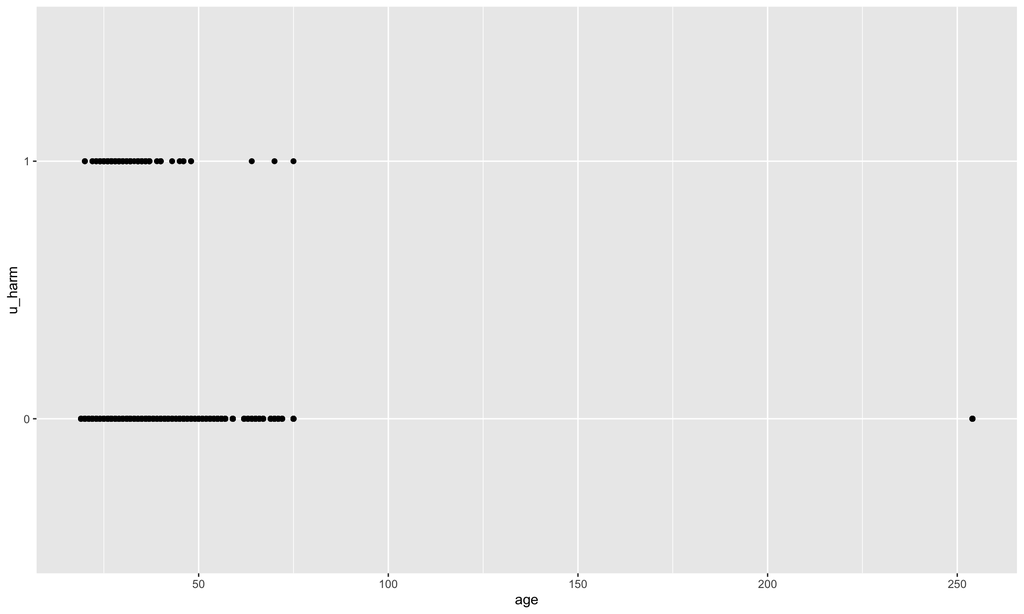

```r
# US were 91/168 = 54% to justified harm

ggplot() + geom_point(aes(x=age, y = u_harm), data1d)
```

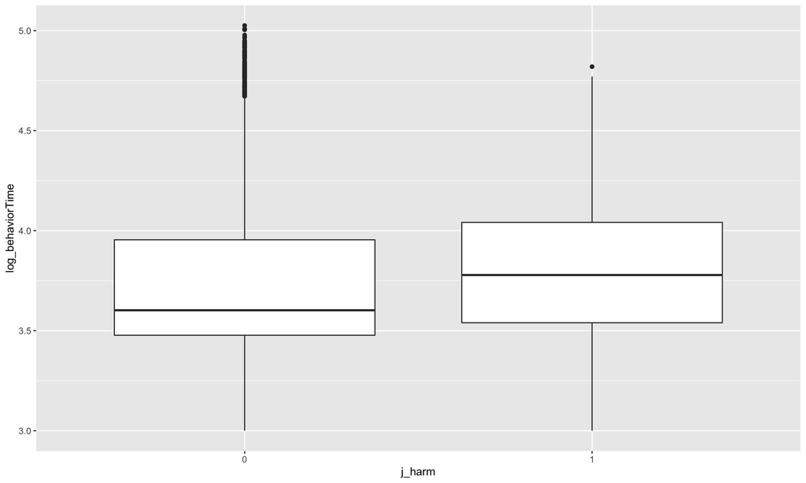

```r
ggplot() + geom_boxplot(aes(x = j_harm, y = log_behaviorTime), data = data1d) #longer for justified harm
```

```r
j_harm_times = data1d %>% filter(j_harm == 1) %>% pull(log_behaviorTime)
u_harm_times = data1d %>% filter(u_harm == 1) %>% pull(log_behaviorTime)
mean(j_harm_times) #3.799
```

```
[1] 3.799754
```

```r
mean(u_harm_times) #3.833
```

```
[1] 3.833516
```

```r
median(j_harm_times)
```

```
[1] 3.778151
```

```r
median(u_harm_times)
```

```
[1] 3.778151
```

```r
t.test(j_harm_times, u_harm_times) #not significant
```

```
    Welch Two Sample t-test

data:  j_harm_times and u_harm_times
t = -1.033, df = 424.64, p-value = 0.3022
alternative hypothesis: true difference in means is not equal to 0
95 percent confidence interval:
 -0.09800371  0.03047998
sample estimates:
mean of x mean of y
 3.799754  3.833516
```

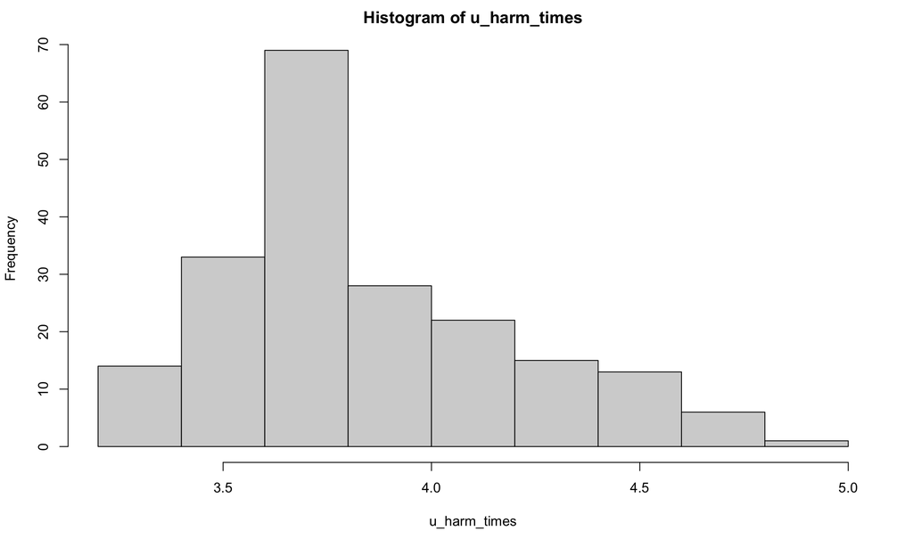

```r
# interesting -
hist(u_harm_times)
```

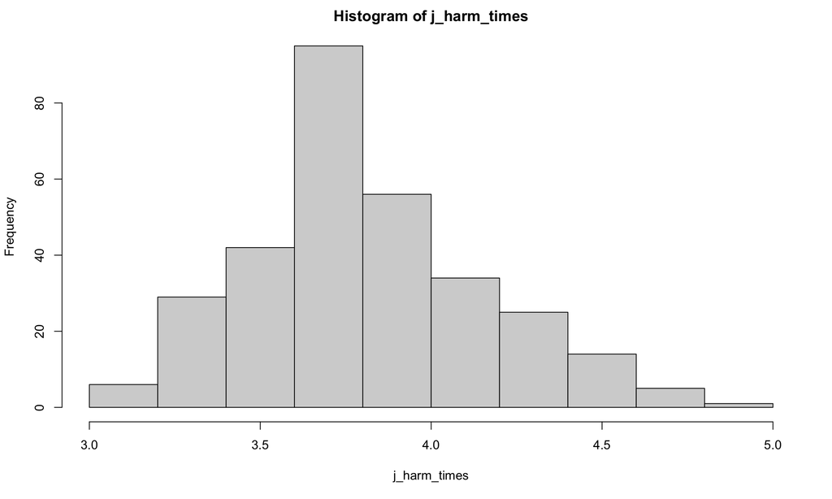

```r
hist(j_harm_times)
```

```r
names(data1)

# Looking at behavior change from coop -> not coop
coop_to_not_coop = data1 %>%
  group_by(game, superid) %>%
  select(superid, game, round, behavior_coop, behavior_defect, behavior_punish,
         behavior_coop_lag, behavior_defect_lag, behavior_punish_lag,
         local_rate_coop, local_rate_defect, local_rate_punish,
         local_rate_coop_lag, local_rate_defect_lag, local_rate_punish_lag,
         initial_coop, initial_defect, initial_punish, log_behaviorTime_lag) %>%
  filter(round != 0, behavior_coop != 1, behavior_coop_lag == 1)

# Confirm that repetition and change differ in time
data2 = data1 %>%
  group_by(game, superid) %>%
  select(superid, game, round, behavior_coop, behavior_defect, behavior_punish,
         behavior_coop_lag, behavior_defect_lag, behavior_punish_lag,
         local_rate_coop, local_rate_defect, local_rate_punish,
         local_rate_coop_lag, local_rate_defect_lag, local_rate_punish_lag,
         initial_coop, initial_defect, initial_punish, log_behaviorTime_lag) %>%
  mutate(behavior = case_when(behavior_coop == 1 ~ "C",
                              behavior_defect == 1 ~ "D",
                              behavior_punish == 1 ~ "P"),
         behavior_lag = case_when(behavior_coop_lag == 1 ~ "C",
                                  behavior_defect_lag == 1 ~ "D",
                                  behavior_punish_lag == 1 ~ "P"),
         repetition = ifelse(behavior == behavior_lag, 1, 0))

# Yes, the mean time for repeated behavior is shorter
data2 %>%
  na.omit() %>%
  ggplot() +
  geom_boxplot(aes(x=factor(repetition, levels = c(1, 0)),
                   y = log_behaviorTime_lag))
rep_times = data2 %>% na.omit() %>%
  filter(repetition == 1) %>% pull(log_behaviorTime_lag)
diff_times = data2 %>% na.omit() %>%
  filter(repetition == 0) %>% pull(log_behaviorTime_lag)
t.test(rep_times, diff_times) # confirmed
```

```r
# Is it different for C-C, D-D, P-P?
data2 %>%
  mutate(rep_cats = case_when(behavior == "C" & behavior_lag == "C" ~ "C-C",
                              behavior == "D" & behavior_lag == "D" ~ "D-D",
                              behavior == "P" & behavior_lag == "P" ~ "P-P")) %>%
  na.omit() %>%
  ggplot() +
  geom_boxplot(aes(x = factor(rep_cats, levels = c("C-C", "D-D", "P-P")),
                   y = log_behaviorTime_lag))
# the median punish time is a bit longer, but not by much - confirms repetition
# is the fastest/easiest regardless of type
```

```r
# Are there differences for the different combinations? CD CP DC DP PC PD
data2 = data2 %>% mutate(diff_cats = case_when(behavior == "C" & behavior_lag == "D" ~ "CD",
                                       behavior == "C" & behavior_lag == "P" ~ "CP",
                                       behavior == "D" & behavior_lag == "C" ~ "DC",
                                       behavior == "D" & behavior_lag == "P" ~ "DP",
                                       behavior == "P" & behavior_lag == "C" ~ "PC",
                                       behavior == "P" & behavior_lag == "D" ~ "PD"))

data2 %>%
  na.omit() %>%
  ggplot() +
  geom_boxplot(aes(x=factor(diff_cats), y = log_behaviorTime_lag))
# Going back to cooperation is faster
```

```r
# C -> P
grouped_means_c_to_p = coop_to_not_coop %>%
  filter(behavior_punish == 1) %>%
  summarize(mean_prev_coop_rate = mean(local_rate_coop_lag),
            mean_prev_def_rate = mean(local_rate_defect_lag),
            mean_prev_punish_rate = mean(local_rate_punish_lag),
            mean_prev_behavior_time = mean(log_behaviorTime_lag))

grouped_means_c_to_p %>% filter(mean_prev_punish_rate == 1)

# Group means
grouped_means_c_to_p %>%
  filter(mean_prev_punish_rate != 0, mean_prev_punish_rate != 1) %>%
  ggplot() +
  geom_point(aes(x=mean_prev_punish_rate,
                 y = mean_prev_behavior_time,
                 color = factor(superid))) +
  geom_smooth(aes(x=mean_prev_punish_rate,
                  y=mean_prev_behavior_time),
              method = "loess", formula = y ~ x)

# View instances of costly punishment

coop_to_not_coop %>%
  filter(behavior_punish == 1, local_rate_coop_lag < 0.5) %>%
  select(superid, game, round, local_rate_coop_lag, local_rate_punish_lag,
         local_rate_coop, local_rate_punish) %>%
  ggplot() +
  geom_point(aes(x=local_rate_punish_lag, local_rate_punish,
                 color = factor(superid)))

# Filter by potential for costly punishment
coop_to_not_coop %>% ungroup() %>%
  filter(local_rate_coop_lag < 0.5) %>%
  summarize(n_defects = sum(behavior_defect),
            n_punish= sum(behavior_punish))
# 297 defects, 104 punishes

c1 = coop_to_not_coop %>%
  filter(local_rate_coop_lag < 0.5) %>%
  mutate(behavior = case_when(behavior_defect == 1 ~ "D",
                              behavior_punish == 1 ~ "P")) %>%
  select(superid, game, round, behavior, local_rate_coop_lag, local_rate_defect_lag,
         local_rate_punish_lag, initial_coop, initial_defect, initial_punish,
         log_behaviorTime_lag) # 4 missing - ignore

c1_clean = na.omit(c1)

c1_clean %>%
  ggplot() + geom_boxplot(aes(x = behavior, y = log_behaviorTime_lag))

# Can we distinguish between costly and non-costly punishment?
coop_to_not_coop %>%
  filter(behavior_punish == 1) %>%
  ggplot() +
  geom_point(aes(x=local_rate_coop_lag, y=log_behaviorTime_lag)) +
  geom_smooth(aes(x=local_rate_coop_lag, y=log_behaviorTime_lag),
              method = "loess", formula = y ~ x)

coop_to_not_coop %>%
  filter(behavior_punish == 1) %>%
  ggplot()+
  geom_histogram(aes(x=local_rate_coop_lag), bins = 10) +
  scale_x_continuous(breaks = c(seq(0, 1, by = 0.1))) # Maybe 3cat - 0-0.25, 0.25-0.5, 0.5+
  # or just 2cat - 0-0.5, 0.5+

coop_to_not_coop = coop_to_not_coop %>%
  mutate(behavior = case_when(behavior_defect == 1 ~ "D",
                              behavior_punish == 1 ~ "P"),
         noncoop_env = ifelse(local_rate_coop_lag < 0.5, 1, 0),
         noncoop_env_3cat = case_when(local_rate_coop_lag >= 0.5 ~ 0,
                                      local_rate_coop_lag >= 0.25 & local_rate_coop_lag < 0.5 ~ 1,
                                      local_rate_coop_lag >= 0 & local_rate_coop_lag <0.25 ~ 2))

xtabs(~noncoop_env + behavior, data = coop_to_not_coop)
xtabs(~noncoop_env_3cat + behavior, data = coop_to_not_coop)
xtabs(~behavior, data=coop_to_not_coop)

coop_to_p = coop_to_not_coop %>%
  filter(behavior == "P")

xtabs(~behavior + noncoop_env_3cat, data = coop_to_p)

coop_to_p %>% na.omit() %>%
  ggplot() +
  geom_boxplot(aes(x=factor(noncoop_env, levels = c(0, 1)), y=log_behaviorTime_lag)) +
  scale_x_discrete(labels = c("Cooperative Environment", "Non-cooperative Environment"))

coop_times = coop_to_p %>% filter(noncoop_env == 0) %>% pull(log_behaviorTime_lag)
non_coop_times = coop_to_p %>% filter(noncoop_env == 1) %>% pull(log_behaviorTime_lag)
t.test(coop_times, non_coop_times, var.equal = F) # no different in time based on environment
```

```
Make decision conflict - when people are cooperative, cooperation should be faster. When people are aggressive, aggression should be faster.

Repetition is easier since you copy what others are doing.

Decision of others in t-1 vs. index individual decision at t
```

### 2. Does longer thinking time stop attacks?

Seems like more deliberation -> higher chance of attack. Less change in terms of rate of cooperation

- Contingency table for behavior time

```r
hist(data1$log_behaviorTime)
quantile(data1$log_behaviorTime, na.rm = T)
quantile(data1_cc$log_behaviorTime)
data1_cc$behaviorTime_cat = case_when(data1_cc$log_behaviorTime >= 3 & data1_cc$log_behaviorTime < 3.4 ~ 0,
                                      data1_cc$log_behaviorTime >= 3.4 & data1_cc$log_behaviorTime < 3.6 ~ 1,
                                      data1_cc$log_behaviorTime >= 3.6 & data1_cc$log_behaviorTime < 3.9 ~ 2,
                                      data1_cc$log_behaviorTime >= 3.9 ~ 3)

round(addmargins(prop.table(xtabs(~behaviorTime_cat + behavior_punish, data1_cc), margin = 1), margin = 2), digits = 3)
round(addmargins(prop.table(xtabs(~behaviorTime_cat + behavior_coop, data1_cc), margin = 1), margin = 2), digits = 3)
```

```r
summary(data1[is.na(data1$behaviorTime)==0 & data1$behaviorTime>=1000 & data1$behaviorTime<3000,]$behavior_coop)
#0.56
summary(data1[is.na(data1$behaviorTime)==0 & data1$behaviorTime>=3000 & data1$behaviorTime<5000,]$behavior_coop)
#0.49
summary(data1[is.na(data1$behaviorTime)==0 & data1$behaviorTime>=5000 & data1$behaviorTime<9000,]$behavior_coop)
#0.49
summary(data1[is.na(data1$behaviorTime)==0 & data1$behaviorTime>=9000 & data1$behaviorTime<1000000,]$behavior_coop)
#0.47

summary(data1[is.na(data1$behaviorTime)==0 & data1$behaviorTime>=1000 & data1$behaviorTime<3000,]$behavior_punish)
#0.03
summary(data1[is.na(data1$behaviorTime)==0 & data1$behaviorTime>=3000 & data1$behaviorTime<5000,]$behavior_punish)
#0.047
summary(data1[is.na(data1$behaviorTime)==0 & data1$behaviorTime>=5000 & data1$behaviorTime<9000,]$behavior_punish)
#0.069
summary(data1[is.na(data1$behaviorTime)==0 & data1$behaviorTime>=9000 & data1$behaviorTime<1000000,]$behavior_punish)
#0.079
```

### 3. What factors stop consecutive attacks?

```
a) Identify attack patterns - first, create a new dataset that characterizes behavior by each actor in consecutive rounds.
```

```r
# Want the unit to be paired values
# Basically want to combine the lag/cumulative values
# Group variables: superid, game
# Unit variables: round (should be round + round+1), behavior in consecutive rounds (i.e. behavior_lag + behavior?)
# Lag + behavior (current round) represents consecutive choices
# Other things: local rate/behavior time/cpayoffs? - want diffs or means/medians?

data1_consecutive = data1_cc

# Create new data where one row = 2 consecutive choices
data1_consecutive = data1_consecutive %>% mutate(behavior = case_when(behavior_coop == 1 ~ "C",
                                                  behavior_defect == 1 ~ "D",
                                                  behavior_punish == 1 ~ "P"),
                             behavior_lag = case_when(behavior_coop_lag == 1 ~ "C",
                                                      behavior_defect_lag == 1 ~ "D",
                                                      behavior_punish_lag == 1 ~ "P"),
                             behavior_pair = paste0(behavior_lag, behavior), #pair is prev+current
                             round_pair = paste0(as.character(round-1), as.character(round)),
                             happ_diff = happ - happ_lag,
                             cPayoffS_diff = cPayoffS - cPayoffS_lag,
                             degree_diff = degree - degree_lag,
                             behaviorTime_diff = behaviorTime - behaviorTime_lag) %>%
                      dplyr::select(superid, behavior_pair, round_pair, age, gender, showScore, initial_score, happ_diff,
                                    cPayoffS_diff, degree_diff, behaviorTime_diff)
```

```r
#Try regression where outcome is behavior pair?
# Exclude round 0/1
# Maybe set CC to reference (most common pair)
`%notin%` <- Negate(`%in%`)
table(data1_consecutive$behavior_pair)
data1_cs_short = data1_consecutive %>% filter(round_pair %notin% c(-10, 01)) %>%
  mutate(behavior_pair = factor(behavior_pair, levels = c("CC", "CD", "CP", "DD", "DC", "DP", "PC", "PD", "PP")),
         behavior_pair2 = case_when(behavior_pair %in% c("CC", "CD", "CP", "DD", "DC", "DP") ~ 0,
                                    behavior_pair == "PC" ~ 1,
                                    behavior_pair == "PD" ~ 2,
                                    behavior_pair == "PP" ~ 3))
```

```r
# Try multinomial regression
names(data1_cs_short)

library(nnet)
library(broom)

model5 = multinom(behavior_pair2 ~ age + gender + showScore + initial_score + happ_diff + cPayoffS_diff + degree_diff + behaviorTime_diff, data = data1_cs_short)
model5_result = tidy(model5, conf.int = T, conf.level = 0.95, exponentiate = TRUE) %>% dplyr::select(y.level, term, estimate, conf.low, conf.high)
model5_coefs = model5_result %>% dplyr::select(estimate, conf.low, conf.high)
model5_result2 = cbind(model5_result$y.level, model5_result$term, model5_coefs)
model5_result2

# model5 = glm(behavior_pair2 ~ age + gender + showScore + initial_score + happ_diff + cPayoffS_diff + degree_diff + behaviorTime_diff, family = "binomial", data = data1_cs_short)
# summary(model5)
```

```r
# Multilevel multinomial?
```

How to visualize this? Network visualization? 2D visual of progress showing each actor’s strategy?

# Next steps for this

Add a lag 2 set of variables

Interaction between lag1 and lag2

## 2. Building a network representation of activity

```r
load("~/Documents/Projects/harming_esn/Data/harming_jsons/ldata4_0316X.Rdata") #ldata4
load("~/Documents/Projects/harming_esn/Data/ndata_individual.Rdata") #ndata1
```

```r
library(igraph)
library(tidygraph)
library(RColorBrewer)

ndata1_r0 = ndata1 %>% filter(game == 1, round == 0) %>% relocate(id)
ndata1_r1 = ndata1 %>% filter(game == 1, round == 1) %>% relocate(id)
ndata1_r2 = ndata1 %>% filter(game == 1, round == 2) %>% relocate(id)
ndata1_r3 = ndata1 %>% filter(game == 1, round == 3) %>% relocate(id)
ndata1_r4 = ndata1 %>% filter(game == 1, round == 4) %>% relocate(id)
ndata1_r5 = ndata1 %>% filter(game == 1, round == 5) %>% relocate(id)
ndata1_r6 = ndata1 %>% filter(game == 1, round == 6) %>% relocate(id)
ndata1_r7 = ndata1 %>% filter(game == 1, round == 7) %>% relocate(id)
ndata1_r8 = ndata1 %>% filter(game == 1, round == 8) %>% relocate(id)
ndata1_r9 = ndata1 %>% filter(game == 1, round == 9) %>% relocate(id)
ndata1_r10 = ndata1 %>% filter(game == 1, round == 10) %>% relocate(id)
ndata1_r11 = ndata1 %>% filter(game == 1, round == 11) %>% relocate(id)
ndata1_r12 = ndata1 %>% filter(game == 1, round == 12) %>% relocate(id)
ndata1_r13 = ndata1 %>% filter(game == 1, round == 13) %>% relocate(id)
ndata1_r14 = ndata1 %>% filter(game == 1, round == 14) %>% relocate(id)
ndata1_r15 = ndata1 %>% filter(game == 1, round == 15) %>% relocate(id)
```

```r
# For game 1
set.seed(123)
game1_round0_edgelist = ldata4 %>% filter(game == 1, round == 0) %>% dplyr::select(id1, id2)
g0 = graph_from_data_frame(game1_round0_edgelist, directed = T, vertices = ndata1_r0)
pal = brewer.pal(length(unique(V(g0)$behavior)), "Set1") #Red = D, Blue = C, Green = P

coords = layout.auto(g0)

game1_round1_edgelist = ldata4 %>% filter(game == 1, round == 1) %>% dplyr::select(id1, id2)
g1 = graph_from_data_frame(game1_round1_edgelist, directed = T, vertices = ndata1_r1)
pal = brewer.pal(length(unique(V(g1)$behavior)), "Set1") #Red = D, Blue = C, Green = P
coords = layout.auto(g1)
plot(g1,
     layout = coords,
     vertex.color = pal[as.numeric(factor(vertex_attr(g0, "behavior"), levels = c("D", "C", "P")))])

game1_round2_edgelist = ldata4 %>% filter(game == 1, round == 2) %>% dplyr::select(id1, id2)
g2 = graph_from_data_frame(game1_round2_edgelist, directed = T, vertices = ndata1_r2)

game1_round3_edgelist = ldata4 %>% filter(game == 1, round == 3) %>% dplyr::select(id1, id2)
g3 = graph_from_data_frame(game1_round3_edgelist, directed = T, vertices = ndata1_r3)

game1_round4_edgelist = ldata4 %>% filter(game == 1, round == 4) %>% dplyr::select(id1, id2)
g4 = graph_from_data_frame(game1_round4_edgelist, directed = T, vertices = ndata1_r4)

game1_round5_edgelist = ldata4 %>% filter(game == 1, round == 5) %>% dplyr::select(id1, id2)
g5 = graph_from_data_frame(game1_round5_edgelist, directed = T, vertices = ndata1_r5)

game1_round6_edgelist = ldata4 %>% filter(game == 1, round == 6) %>% dplyr::select(id1, id2)
g6 = graph_from_data_frame(game1_round6_edgelist, directed = T, vertices = ndata1_r6)

game1_round7_edgelist = ldata4 %>% filter(game == 1, round == 7) %>% dplyr::select(id1, id2)
g7 = graph_from_data_frame(game1_round7_edgelist, directed = T, vertices = ndata1_r7)

game1_round8_edgelist = ldata4 %>% filter(game == 1, round == 8) %>% dplyr::select(id1, id2)
g8 = graph_from_data_frame(game1_round8_edgelist, directed = T, vertices = ndata1_r8)

game1_round9_edgelist = ldata4 %>% filter(game == 1, round == 9) %>% dplyr::select(id1, id2)
g9 = graph_from_data_frame(game1_round9_edgelist, directed = T, vertices = ndata1_r9)

game1_round10_edgelist = ldata4 %>% filter(game == 1, round == 10) %>% dplyr::select(id1, id2)
g10 = graph_from_data_frame(game1_round10_edgelist, directed = T, vertices = ndata1_r10)

game1_round11_edgelist = ldata4 %>% filter(game == 1, round == 11) %>% dplyr::select(id1, id2)
g11 = graph_from_data_frame(game1_round11_edgelist, directed = T, vertices = ndata1_r11)

game1_round12_edgelist = ldata4 %>% filter(game == 1, round == 12) %>% dplyr::select(id1, id2)
g12 = graph_from_data_frame(game1_round12_edgelist, directed = T, vertices = ndata1_r12)

game1_round13_edgelist = ldata4 %>% filter(game == 1, round == 13) %>% dplyr::select(id1, id2)
g13 = graph_from_data_frame(game1_round13_edgelist, directed = T, vertices = ndata1_r13)

game1_round14_edgelist = ldata4 %>% filter(game == 1, round == 14) %>% dplyr::select(id1, id2)
g14 = graph_from_data_frame(game1_round14_edgelist, directed = T, vertices = ndata1_r14)

game1_round15_edgelist = ldata4 %>% filter(game == 1, round == 15) %>% dplyr::select(id1, id2)
g15 = graph_from_data_frame(game1_round15_edgelist, directed = T, vertices = ndata1_r15)

# Create animation
saveGIF({
  plot(g1,
     layout = coords,
     vertex.color = pal[as.numeric(factor(vertex_attr(g1, "behavior"), levels = c("D", "C", "P")))])
  plot(g2,
     layout = coords,
     vertex.color = pal[as.numeric(factor(vertex_attr(g2, "behavior"), levels = c("D", "C", "P")))])
  plot(g3,
     layout = coords,
     vertex.color = pal[as.numeric(factor(vertex_attr(g3, "behavior"), levels = c("D", "C", "P")))])
  plot(g4,
     layout = coords,
     vertex.color = pal[as.numeric(factor(vertex_attr(g4, "behavior"), levels = c("D", "C", "P")))])
  plot(g5,
     layout = coords,
     vertex.color = pal[as.numeric(factor(vertex_attr(g5, "behavior"), levels = c("D", "C", "P")))])
  plot(g6,
     layout = coords,
     vertex.color = pal[as.numeric(factor(vertex_attr(g6, "behavior"), levels = c("D", "C", "P")))])
  plot(g7,
     layout = coords,
     vertex.color = pal[as.numeric(factor(vertex_attr(g7, "behavior"), levels = c("D", "C", "P")))])
  plot(g8,
     layout = coords,
     vertex.color = pal[as.numeric(factor(vertex_attr(g8, "behavior"), levels = c("D", "C", "P")))])
  plot(g9,
     layout = coords,
     vertex.color = pal[as.numeric(factor(vertex_attr(g9, "behavior"), levels = c("D", "C", "P")))])
  plot(g10,
     layout = coords,
     vertex.color = pal[as.numeric(factor(vertex_attr(g10, "behavior"), levels = c("D", "C", "P")))])
  plot(g11,
     layout = coords,
     vertex.color = pal[as.numeric(factor(vertex_attr(g11, "behavior"), levels = c("D", "C", "P")))])
  plot(g12,
     layout = coords,
     vertex.color = pal[as.numeric(factor(vertex_attr(g12, "behavior"), levels = c("D", "C", "P")))])
  plot(g13,
     layout = coords,
     vertex.color = pal[as.numeric(factor(vertex_attr(g13, "behavior"), levels = c("D", "C", "P")))])
  plot(g14,
     layout = coords,
     vertex.color = pal[as.numeric(factor(vertex_attr(g14, "behavior"), levels = c("D", "C", "P")))])
  plot(g15,
     layout = coords,
     vertex.color = pal[as.numeric(factor(vertex_attr(g15, "behavior"), levels = c("D", "C", "P")))])
  },
  interval = 0.65, movie.name = "game1.gif")
```

```r
#Game 40
# ndata1_r0 = ndata1 %>% filter(game == 40, round == 0) %>% relocate(id) %>% unnest()
ndata1_r1 = ndata1 %>% filter(game == 40, round == 1) %>% relocate(id)
ndata1_r2 = ndata1 %>% filter(game == 40, round == 2) %>% relocate(id)
ndata1_r3 = ndata1 %>% filter(game == 40, round == 3) %>% relocate(id)
ndata1_r4 = ndata1 %>% filter(game == 40, round == 4) %>% relocate(id)
ndata1_r5 = ndata1 %>% filter(game == 40, round == 5) %>% relocate(id)
ndata1_r6 = ndata1 %>% filter(game == 40, round == 6) %>% relocate(id)
ndata1_r7 = ndata1 %>% filter(game == 40, round == 7) %>% relocate(id)
ndata1_r8 = ndata1 %>% filter(game == 40, round == 8) %>% relocate(id)
ndata1_r9 = ndata1 %>% filter(game == 40, round == 9) %>% relocate(id)
ndata1_r10 = ndata1 %>% filter(game == 40, round == 10) %>% relocate(id)
ndata1_r11 = ndata1 %>% filter(game == 40, round == 11) %>% relocate(id)
ndata1_r12 = ndata1 %>% filter(game == 40, round == 12) %>% relocate(id)
ndata1_r13 = ndata1 %>% filter(game == 40, round == 13) %>% relocate(id)
ndata1_r14 = ndata1 %>% filter(game == 40, round == 14) %>% relocate(id)
ndata1_r15 = ndata1 %>% filter(game == 40, round == 15) %>% relocate(id)

game40_round1_edgelist = ldata4 %>% filter(game == 40, round == 1) %>% dplyr::select(id1, id2)
g1 = graph_from_data_frame(game40_round1_edgelist, directed = T, vertices = ndata1_r1)
pal = brewer.pal(length(unique(V(g1)$behavior)), "Set1") #Red = D, Blue = C, Green = P
coords = layout.auto(g1)

game40_round2_edgelist = ldata4 %>% filter(game == 40, round == 2) %>% dplyr::select(id1, id2)
g2 = graph_from_data_frame(game40_round2_edgelist, directed = T, vertices = ndata1_r2)

game40_round3_edgelist = ldata4 %>% filter(game == 40, round == 3) %>% dplyr::select(id1, id2)
g3 = graph_from_data_frame(game40_round3_edgelist, directed = T, vertices = ndata1_r3)

game40_round4_edgelist = ldata4 %>% filter(game == 40, round == 4) %>% dplyr::select(id1, id2)
g4 = graph_from_data_frame(game40_round4_edgelist, directed = T, vertices = ndata1_r4)

game40_round5_edgelist = ldata4 %>% filter(game == 40, round == 5) %>% dplyr::select(id1, id2)
g5 = graph_from_data_frame(game40_round5_edgelist, directed = T, vertices = ndata1_r5)

game40_round6_edgelist = ldata4 %>% filter(game == 40, round == 6) %>% dplyr::select(id1, id2)
g6 = graph_from_data_frame(game40_round6_edgelist, directed = T, vertices = ndata1_r6)

game40_round7_edgelist = ldata4 %>% filter(game == 40, round == 7) %>% dplyr::select(id1, id2)
g7 = graph_from_data_frame(game40_round7_edgelist, directed = T, vertices = ndata1_r7)

game40_round8_edgelist = ldata4 %>% filter(game == 40, round == 8) %>% dplyr::select(id1, id2)
g8 = graph_from_data_frame(game40_round8_edgelist, directed = T, vertices = ndata1_r8)

game40_round9_edgelist = ldata4 %>% filter(game == 40, round == 9) %>% dplyr::select(id1, id2)
g9 = graph_from_data_frame(game40_round9_edgelist, directed = T, vertices = ndata1_r9)

game40_round10_edgelist = ldata4 %>% filter(game == 40, round == 10) %>% dplyr::select(id1, id2)
g10 = graph_from_data_frame(game40_round10_edgelist, directed = T, vertices = ndata1_r10)

game40_round11_edgelist = ldata4 %>% filter(game == 40, round == 11) %>% dplyr::select(id1, id2)
g11 = graph_from_data_frame(game40_round11_edgelist, directed = T, vertices = ndata1_r11)

game40_round12_edgelist = ldata4 %>% filter(game == 40, round == 12) %>% dplyr::select(id1, id2)
g12 = graph_from_data_frame(game40_round12_edgelist, directed = T, vertices = ndata1_r12)

game40_round13_edgelist = ldata4 %>% filter(game == 40, round == 13) %>% dplyr::select(id1, id2)
g13 = graph_from_data_frame(game40_round13_edgelist, directed = T, vertices = ndata1_r13)

game40_round14_edgelist = ldata4 %>% filter(game == 40, round == 14) %>% dplyr::select(id1, id2)
g14 = graph_from_data_frame(game40_round14_edgelist, directed = T, vertices = ndata1_r14)

game40_round15_edgelist = ldata4 %>% filter(game == 40, round == 15) %>% dplyr::select(id1, id2)
g15 = graph_from_data_frame(game40_round15_edgelist, directed = T, vertices = ndata1_r15)

# Game 40 animation
library(animation)

saveGIF({
  plot(g0,
     layout = coords,
     vertex.label = NA,
     vertex.color = pal[as.numeric(factor(vertex_attr(g0, "behavior"), levels = c("D", "C", "P")))])
  plot(g1,
     layout = coords,
     vertex.label = NA,
     vertex.color = pal[as.numeric(factor(vertex_attr(g1, "behavior"), levels = c("D", "C", "P")))])
  plot(g2,
     layout = coords,
     vertex.label = NA,
     vertex.color = pal[as.numeric(factor(vertex_attr(g2, "behavior"), levels = c("D", "C", "P")))])
  plot(g3,
     layout = coords,
     vertex.label = NA,
     vertex.color = pal[as.numeric(factor(vertex_attr(g3, "behavior"), levels = c("D", "C", "P")))])
  plot(g4,
     layout = coords,
     vertex.label = NA,
     vertex.color = pal[as.numeric(factor(vertex_attr(g4, "behavior"), levels = c("D", "C", "P")))])
  plot(g5,
     layout = coords,
     vertex.label = NA,
     vertex.color = pal[as.numeric(factor(vertex_attr(g5, "behavior"), levels = c("D", "C", "P")))])
  plot(g6,
     layout = coords,
     vertex.label = NA,
     vertex.color = pal[as.numeric(factor(vertex_attr(g6, "behavior"), levels = c("D", "C", "P")))])
  plot(g7,
     layout = coords,
     vertex.label = NA,
     vertex.color = pal[as.numeric(factor(vertex_attr(g7, "behavior"), levels = c("D", "C", "P")))])
  plot(g8,
     layout = coords,
     vertex.label = NA,
     vertex.color = pal[as.numeric(factor(vertex_attr(g8, "behavior"), levels = c("D", "C", "P")))])
  plot(g9,
     layout = coords,
     vertex.label = NA,
     vertex.color = pal[as.numeric(factor(vertex_attr(g9, "behavior"), levels = c("D", "C", "P")))])
  plot(g10,
     layout = coords,
     vertex.label = NA,
     vertex.color = pal[as.numeric(factor(vertex_attr(g10, "behavior"), levels = c("D", "C", "P")))])
  plot(g11,
     layout = coords,
     vertex.label = NA,
     vertex.color = pal[as.numeric(factor(vertex_attr(g11, "behavior"), levels = c("D", "C", "P")))])
  plot(g12,
     layout = coords,
     vertex.label = NA,
     vertex.color = pal[as.numeric(factor(vertex_attr(g12, "behavior"), levels = c("D", "C", "P")))])
  plot(g13,
     layout = coords,
     vertex.label = NA,
     vertex.color = pal[as.numeric(factor(vertex_attr(g13, "behavior"), levels = c("D", "C", "P")))])
  plot(g14,
     layout = coords,
     vertex.label = NA,
     vertex.color = pal[as.numeric(factor(vertex_attr(g14, "behavior"), levels = c("D", "C", "P")))])
  plot(g15,
     layout = coords,
     vertex.label = NA,
     vertex.color = pal[as.numeric(factor(vertex_attr(g15, "behavior"), levels = c("D", "C", "P")))])
  },
  interval = 0.65, movie.name = "game40.gif")
```

```r
#Game 44
# ndata1_r0 = ndata1 %>% filter(game == 44, round == 0) %>% relocate(id) %>% unnest()
ndata1_r1 = ndata1 %>% filter(game == 44, round == 1) %>% relocate(id)
ndata1_r2 = ndata1 %>% filter(game == 44, round == 2) %>% relocate(id)
ndata1_r3 = ndata1 %>% filter(game == 44, round == 3) %>% relocate(id)
ndata1_r4 = ndata1 %>% filter(game == 44, round == 4) %>% relocate(id)
ndata1_r5 = ndata1 %>% filter(game == 44, round == 5) %>% relocate(id)
ndata1_r6 = ndata1 %>% filter(game == 44, round == 6) %>% relocate(id)
ndata1_r7 = ndata1 %>% filter(game == 44, round == 7) %>% relocate(id)
ndata1_r8 = ndata1 %>% filter(game == 44, round == 8) %>% relocate(id)
ndata1_r9 = ndata1 %>% filter(game == 44, round == 9) %>% relocate(id)
ndata1_r10 = ndata1 %>% filter(game == 44, round == 10) %>% relocate(id)
ndata1_r11 = ndata1 %>% filter(game == 44, round == 11) %>% relocate(id)
ndata1_r12 = ndata1 %>% filter(game == 44, round == 12) %>% relocate(id)
ndata1_r13 = ndata1 %>% filter(game == 44, round == 13) %>% relocate(id)
ndata1_r14 = ndata1 %>% filter(game == 44, round == 14) %>% relocate(id)
ndata1_r15 = ndata1 %>% filter(game == 44, round == 15) %>% relocate(id)

game44_round1_edgelist = ldata4 %>% filter(game == 44, round == 1) %>% dplyr::select(id1, id2)
g1 = graph_from_data_frame(game44_round1_edgelist, directed = T, vertices = ndata1_r1)
pal = brewer.pal(length(unique(V(g1)$behavior)), "Set1") #Red = D, Blue = C, Green = P
coords = layout.auto(g1)

game44_round2_edgelist = ldata4 %>% filter(game == 44, round == 2) %>% dplyr::select(id1, id2)
g2 = graph_from_data_frame(game44_round2_edgelist, directed = T, vertices = ndata1_r2)

game44_round3_edgelist = ldata4 %>% filter(game == 44, round == 3) %>% dplyr::select(id1, id2)
g3 = graph_from_data_frame(game44_round3_edgelist, directed = T, vertices = ndata1_r3)

game44_round4_edgelist = ldata4 %>% filter(game == 44, round == 4) %>% dplyr::select(id1, id2)
g4 = graph_from_data_frame(game44_round4_edgelist, directed = T, vertices = ndata1_r4)

game44_round5_edgelist = ldata4 %>% filter(game == 44, round == 5) %>% dplyr::select(id1, id2)
g5 = graph_from_data_frame(game44_round5_edgelist, directed = T, vertices = ndata1_r5)

game44_round6_edgelist = ldata4 %>% filter(game == 44, round == 6) %>% dplyr::select(id1, id2)
g6 = graph_from_data_frame(game44_round6_edgelist, directed = T, vertices = ndata1_r6)

game44_round7_edgelist = ldata4 %>% filter(game == 44, round == 7) %>% dplyr::select(id1, id2)
g7 = graph_from_data_frame(game44_round7_edgelist, directed = T, vertices = ndata1_r7)

game44_round8_edgelist = ldata4 %>% filter(game == 44, round == 8) %>% dplyr::select(id1, id2)
g8 = graph_from_data_frame(game44_round8_edgelist, directed = T, vertices = ndata1_r8)

game44_round9_edgelist = ldata4 %>% filter(game == 44, round == 9) %>% dplyr::select(id1, id2)
g9 = graph_from_data_frame(game44_round9_edgelist, directed = T, vertices = ndata1_r9)

game44_round10_edgelist = ldata4 %>% filter(game == 44, round == 10) %>% dplyr::select(id1, id2)
g10 = graph_from_data_frame(game44_round10_edgelist, directed = T, vertices = ndata1_r10)

game44_round11_edgelist = ldata4 %>% filter(game == 44, round == 11) %>% dplyr::select(id1, id2)
g11 = graph_from_data_frame(game44_round11_edgelist, directed = T, vertices = ndata1_r11)

game44_round12_edgelist = ldata4 %>% filter(game == 44, round == 12) %>% dplyr::select(id1, id2)
g12 = graph_from_data_frame(game44_round12_edgelist, directed = T, vertices = ndata1_r12)

game44_round13_edgelist = ldata4 %>% filter(game == 44, round == 13) %>% dplyr::select(id1, id2)
g13 = graph_from_data_frame(game44_round13_edgelist, directed = T, vertices = ndata1_r13)

game44_round14_edgelist = ldata4 %>% filter(game == 44, round == 14) %>% dplyr::select(id1, id2)
g14 = graph_from_data_frame(game44_round14_edgelist, directed = T, vertices = ndata1_r14)

game44_round15_edgelist = ldata4 %>% filter(game == 44, round == 15) %>% dplyr::select(id1, id2)
g15 = graph_from_data_frame(game44_round15_edgelist, directed = T, vertices = ndata1_r15)

# Game 44 animation
library(animation)

saveGIF({
  plot(g1,
     layout = coords,
     vertex.label = NA,
     vertex.color = pal[as.numeric(factor(vertex_attr(g1, "behavior"), levels = c("D", "C", "P")))])
  plot(g2,
     layout = coords,
     vertex.label = NA,
     vertex.color = pal[as.numeric(factor(vertex_attr(g2, "behavior"), levels = c("D", "C", "P")))])
  plot(g3,
     layout = coords,
     vertex.label = NA,
     vertex.color = pal[as.numeric(factor(vertex_attr(g3, "behavior"), levels = c("D", "C", "P")))])
  plot(g4,
     layout = coords,
     vertex.label = NA,
     vertex.color = pal[as.numeric(factor(vertex_attr(g4, "behavior"), levels = c("D", "C", "P")))])
  plot(g5,
     layout = coords,
     vertex.label = NA,
     vertex.color = pal[as.numeric(factor(vertex_attr(g5, "behavior"), levels = c("D", "C", "P")))])
  plot(g6,
     layout = coords,
     vertex.label = NA,
     vertex.color = pal[as.numeric(factor(vertex_attr(g6, "behavior"), levels = c("D", "C", "P")))])
  plot(g7,
     layout = coords,
     vertex.label = NA,
     vertex.color = pal[as.numeric(factor(vertex_attr(g7, "behavior"), levels = c("D", "C", "P")))])
  plot(g8,
     layout = coords,
     vertex.label = NA,
     vertex.color = pal[as.numeric(factor(vertex_attr(g8, "behavior"), levels = c("D", "C", "P")))])
  plot(g9,
     layout = coords,
     vertex.label = NA,
     vertex.color = pal[as.numeric(factor(vertex_attr(g9, "behavior"), levels = c("D", "C", "P")))])
  plot(g10,
     layout = coords,
     vertex.label = NA,
     vertex.color = pal[as.numeric(factor(vertex_attr(g10, "behavior"), levels = c("D", "C", "P")))])
  plot(g11,
     layout = coords,
     vertex.label = NA,
     vertex.color = pal[as.numeric(factor(vertex_attr(g11, "behavior"), levels = c("D", "C", "P")))])
  plot(g12,
     layout = coords,
     vertex.label = NA,
     vertex.color = pal[as.numeric(factor(vertex_attr(g12, "behavior"), levels = c("D", "C", "P")))])
  plot(g13,
     layout = coords,
     vertex.label = NA,
     vertex.color = pal[as.numeric(factor(vertex_attr(g13, "behavior"), levels = c("D", "C", "P")))])
  plot(g14,
     layout = coords,
     vertex.label = NA,
     vertex.color = pal[as.numeric(factor(vertex_attr(g14, "behavior"), levels = c("D", "C", "P")))])
  plot(g15,
     layout = coords,
     vertex.label = NA,
     vertex.color = pal[as.numeric(factor(vertex_attr(g15, "behavior"), levels = c("D", "C", "P")))])
  },
  interval = 0.65, movie.name = "game44.gif")
```

## 3. Determining the influence of different harming patterns

```r
data3 = data1 %>%
  filter(round != 0) %>%
  mutate(count_local_coop_lag = e_degree * local_rate_coop_lag,
         count_local_defect_lag = e_degree * local_rate_defect_lag,
         count_local_punish_lag = e_degree *  local_rate_punish_lag)
hist(data3$count_local_coop_lag)
hist(data3$count_local_defect_lag)
hist(data3$count_local_punish_lag)
```

```r
data3 %>%
  filter(count_local_coop_lag == 0) %>%
  ggplot() +
  geom_histogram(aes(x = e_degree), bins = 20)

data3 %>% filter(count_local_punish_lag >= 2)

# decision -> see results of others -> rewire || round start || decision -> ..

# Counts

data3 %>% filter(count_local_punish_lag >= 2) %>% tally(behavior_coop) #78
data3 %>% filter(count_local_punish_lag >= 2) %>% tally(behavior_defect) #172
data3 %>% filter(count_local_punish_lag >= 2) %>% tally(behavior_punish) #17
# Coop rate - 78/267 = 29%, Defect rate = 64%, Punish rate = 6.4%
17/267

data3 %>% filter(count_local_punish_lag == 1) %>% tally(behavior_coop) #217
data3 %>% filter(count_local_punish_lag == 1) %>% tally(behavior_defect) #300
data3 %>% filter(count_local_punish_lag == 1) %>% tally(behavior_punish) #38)
# Coop rate - 217/555 = 39%, defect rate = 54%, punish rate = 6.8%

data3 %>% filter(count_local_punish_lag == 0) %>% tally(behavior_coop) #3632
data3 %>% filter(count_local_punish_lag == 0) %>% tally(behavior_defect) #2869
data3 %>% filter(count_local_punish_lag == 0) %>% tally(behavior_punish) #359
# C: 3632/6860 = 53%, D: 42%, P: 5.2%

# Proportions
data3 %>% filter(local_rate_punish_lag >= 0.15) %>% tally(behavior_coop) #437
data3 %>% filter(local_rate_punish_lag >= 0.15) %>% tally(behavior_defect) #728
data3 %>% filter(local_rate_punish_lag >= 0.15) %>% tally(behavior_punish) #104
# 34%/57%/8.2%

data3 %>% filter(local_rate_punish_lag > 0 & local_rate_punish_lag < 0.15) %>% tally(behavior_coop) #426
data3 %>% filter(local_rate_punish_lag > 0 & local_rate_punish_lag < 0.15) %>% tally(behavior_defect) #420
data3 %>% filter(local_rate_punish_lag > 0 & local_rate_punish_lag < 0.15) %>% tally(behavior_punish) #45
# 47.8/47.1/5.05

data3 %>% filter(local_rate_punish_lag == 0) %>% tally(behavior_coop) #3632
data3 %>% filter(local_rate_punish_lag == 0) %>% tally(behavior_defect) #2869
data3 %>% filter(local_rate_punish_lag == 0) %>% tally(behavior_punish) #359
# 53/42/5.23

hist(data3$local_rate_punish_lag)
```

** Things to do ** - OR was 1.08 but in 2x2 the result was flipped. How does this happen? Because rd0 data is excluded - What is the correct threshold for the local rate? can increase the # of categories - threshold breaks the dose-response relationship. Where does the curve go in the end?

Next: how to show this in regression model?

```r
load("~/Documents/Projects/harming_esn/Data/nodedataHarming.rdata")
names(ndata)
#ndata is the node data
harmdata = ndata
#making superid
table(ndata$game)

harmdata$superid = 20000 + 100 * harmdata$game +
  as.numeric(substr(harmdata$id,2,nchar(harmdata$id)))
#2XXXX for the harming experiment

#local_rate_coop and other detailed data
#This will be done when we need other variables.
#mdata2 is the link data
load("~/Documents/Projects/harming_esn/Data/Harminglinknodedata.Rdata")
harmlinknode = mdata2
harmlinknode = harmlinknode[,c("superid", "round",
                               "cur_local_rate_coop", "n_ties")]
names(harmlinknode)[3] = "local_rate_coop"
names(harmlinknode)[4] = "degree"
harmlinknode$superid = 20000 + harmlinknode$superid
harmdata = merge(x = harmdata,
                 y = harmlinknode,
                 by = c("superid","round"), all=T) #10727
names(harmdata)

###a function to standardize
standardize = function(x) {
  mu = mean(x, na.rm = T)
  sd = sd(x, na.rm = T)
  return ((x - mu)/sd)
}

###making a continuous variable of happiness
harmdata$happ = ifelse(harmdata$satisfaction == "v_good", 2,
                 ifelse(harmdata$satisfaction == "good", 1,
                 ifelse(harmdata$satisfaction == "neutral", 0,
                 ifelse(harmdata$satisfaction == "bad", -1,
                 ifelse(harmdata$satisfaction == "v_bad", -2, NA)))))

###making PosWealth (when <0, 0)
harmdata$PosWealth = ifelse(harmdata$cumulativePayoff >= 0,
                            harmdata$cumulativePayoff, 0)

#making cPayoffS (standardized cumulative payoff,
#gini_wealth, and gini_wellbeing)
HarmStandard = as.data.frame(matrix(NA, ncol = ncol(harmdata) + 3, nrow = 0))
names(HarmStandard) = c(names(harmdata), "cPayoffS", "gini_wealth",
                        "gini_wellbeing")
for (i in 0:max(harmdata$round)){   #number of rounds
  for (j in 1:max(harmdata$game)){ #number of games
    temp = harmdata[(harmdata$game == j & harmdata$round == i), ]
    temp$cPayoffS = standardize(temp$cumulativePayoff)
    temp$gini_wealth = gini(temp$PosWealth)
    temp$gini_wellbeing = gini(temp$happ)
    HarmStandard = rbind(HarmStandard, temp)
  }
}

###Making 5 wealth categories
HarmStandard = HarmStandard %>%
  mutate(WealthLevel = case_when(cPayoffS < -1.5 ~ "Poorest",
                                 cPayoffS >= -1.5 & cPayoffS < -0.5  ~ "Poorer",
                                 cPayoffS >= -0.5 & cPayoffS < 0.5  ~ "Middle",
                                 cPayoffS >= 0.5 & cPayoffS < 1.5  ~ "Richer",
                                 cPayoffS >= 1.5  ~ "Richest"))

#Making a 0/1 cooperation variable
HarmStandard = HarmStandard %>%
  mutate(coop = case_when(behavior == "C" ~ 1,behavior %in% c("D","P","") ~ 0))

HarmStandard$showScore = ifelse(HarmStandard$showScore=="true",1,0)

###Renaming game ID as well (1XX for Happ, 2XX for Harm)
HarmStandard$game = 200 + HarmStandard$game

###making the variable names the same over the two data
HarmStandard = HarmStandard[,!(names(HarmStandard) == "gameNumber")]

#Harm variable
HarmStandard$harm = ifelse(HarmStandard$behavior=="P",1,0)

#Other variables
HarmStandard$age = as.numeric(unlist(HarmStandard$age))
HarmStandard$gender = as.character(unlist(HarmStandard$gender))
HarmStandard$behaviorTime = as.numeric(unlist(HarmStandard$behaviorTime))

#Making the minimum data
names(HarmStandard)
HarmStandard %>% dplyr::select(game, superid, round, age, gender, showScore,
                               initScore, payoff, cumulativePayoff, cPayoffS,
                               WealthLevel, coop, local_rate_coop, degree, happ,
                               harm,behaviorTime)
data0  = HarmStandard[,c("game","superid","round","age","gender","showScore",
                         "initScore","payoff","cumulativePayoff","cPayoffS",
                         "WealthLevel","coop","local_rate_coop","degree",
                         "happ","harm","behaviorTime")]

#Making a lag data
data_lag = data0[,c("superid","round",
                    "initScore","payoff","cumulativePayoff","cPayoffS",
                    "WealthLevel","coop","local_rate_coop","degree",
                    "happ","harm","behaviorTime")]
names(data_lag)[-c(1,2)] = paste0(names(data_lag)[-c(1,2)],"_lag")
data_lag$round = data_lag$round + 1

#merge
data1 = merge(x=data0,y=data_lag,all.x=T,all.y=F,by=c("superid","round"))

data1$log_behaviorTime = log10(data1$behaviorTime)
data1$log_behaviorTime_lag = log10(data1$behaviorTime_lag)

#checking for data consistency
table(data1$coop) # difference is the blanks were not converted to not coop
# 5104/4878

summary(zelig(data = data1, coop ~ showScore + age + gender, model = "logit"))
# showscore = -0.195
```